# Explorando los datos

Para que esta libreta funcione correctamente es necesario tener cargados los datos de la primera: Análisis de d atos.

Vamos a explorar algunas de las variables que más interesantes nos parecen. Para eso, primero recordaremos cuáles teníamos.

```r
colnames(chuvi)
```

```
 [1] "SN"                               "Camaras"
 [3] "Modelo"                           "Fecha.implante"
 [5] "Tiempo.inicio.ultima.cita"        "Tiempo.inicio.ultimo.seguimiento"
 [7] "Fecha"                            "Fecha.cita.anterior"
 [9] "Fecha.ultima.cita.registrada"     "Fecha.ultimo.seguimiento"
[11] "Tiempo.desde.implante"            "Tiempo.desde.cita.anterior"
[13] "Tiempo.hasta.ultima.cita"         "Tiempo.hasta.ultimo.seguimiento"
[15] "ERI.alcanzado"                    "Voltaje.bateria"
[17] "x18M"                             "x12M"
[19] "x6M"                              "x3M"
[21] "Supervivencia"                    "x18M (ERI)"
[23] "x12M (ERI)"                       "x6M (ERI)"
[25] "x3M (ERI)"                        "STIMA"
[27] "STIMVD"                           "STIMVI"
[29] "Choque"                           "ATP"
[31] "Frecuencia.min"                   "R"
[33] "VA"                               "MSA"
[35] "VD"                               "MSVD"
[37] "VI"                               "MSVI"
[39] "Episodios"                        "Camaras.factor"
[41] "ERI.alcanzado.factor"             "x3M.factor"
[43] "x6M.factor"                       "x12M.factor"
[45] "x18M.factor"                      "Supervivencia.factor"
[47] "R.factor"                         "VA.factor"
[49] "MSA.factor"                       "VD.factor"
[51] "MSVD.factor"                      "VI.factor"
[53] "MSVI.factor"                      "Episodios.factor"
```

Las variables que más interesantes nos parecen son:

```r
summary(chuvi[c("Tiempo.inicio.ultimo.seguimiento","Tiempo.desde.implante","Tiempo.hasta.ultimo.seguimiento","Voltaje.bateria","STIMA","STIMVD","STIMVI","Choque","ATP","Frecuencia.min","Camaras.factor","ERI.alcanzado.factor","x3M.factor","x6M.factor","x12M.factor","x18M.factor","Supervivencia.factor","R.factor","VA.factor","MSA.factor","VD.factor","MSVD.factor","VI.factor","MSVI.factor","Episodios.factor")])
```

```
 Tiempo.inicio.ultimo.seguimiento Tiempo.desde.implante Tiempo.hasta.ultimo.seguimiento
 Min.   :1812                     Min.   :  63          Min.   :   0.0
 1st Qu.:1945                     1st Qu.:1284          1st Qu.: 199.5
 Median :1946                     Median :1780          Median : 462.0
 Mean   :2131                     Mean   :1727          Mean   : 582.8
 3rd Qu.:2448                     3rd Qu.:2217          3rd Qu.: 927.0
 Max.   :2512                     Max.   :3414          Max.   :1644.0
 NA's   :485                                            NA's   :485
 Voltaje.bateria     STIMA            STIMVD           STIMVI           Choque
 Min.   :4.440   Min.   :  0.00   Min.   :  0.00   Min.   : 58.00   Min.   : 0.0000
 1st Qu.:5.130   1st Qu.:  1.00   1st Qu.:  0.00   1st Qu.: 94.00   1st Qu.: 0.0000
 Median :5.170   Median : 14.00   Median :  0.00   Median : 97.00   Median : 0.0000
 Mean   :5.392   Mean   : 35.01   Mean   : 34.33   Mean   : 94.97   Mean   : 0.2293
 3rd Qu.:5.690   3rd Qu.: 74.00   3rd Qu.: 91.00   3rd Qu.: 98.25   3rd Qu.: 0.0000
 Max.   :6.500   Max.   :100.00   Max.   :100.00   Max.   :100.00   Max.   :20.0000
                 NA's   :69                        NA's   :460      NA's   :84
      ATP           Frecuencia.min  Camaras.factor ERI.alcanzado.factor x3M.factor x6M.factor
 Min.   :   0.000   Min.   :30.00   1: 69          NO:495               NO  :  1   NO  :  3
 1st Qu.:   0.000   1st Qu.:50.00   2:391          SI: 29               SI  :431   SI  :395
 Median :   0.000   Median :60.00   3: 64                               NA's: 92   NA's:126
 Mean   :   4.602   Mean   :55.94
 3rd Qu.:   0.000   3rd Qu.:60.00
 Max.   :1107.000   Max.   :80.00
 NA's   :84
 x12M.factor x18M.factor    Supervivencia.factor R.factor     VA.factor   MSA.factor
 NO  :  9    NO  : 16    entre 12 y 6 :  6       No  :327   2.5    :188   0   :  2
 SI  :326    SI  :263    entre 18 y 12:  7       Si  :184   2      :184   0.35:392
 NA's:189    NA's:245    entre 6 y 3  :  2       NA's: 13   3.5    : 55   0.5 : 51
                         más de 18    :263                  1.5    : 10   0.6 : 10
                         menos de 3   :  1                  4      :  7   NA's: 69
                         NA's         :245                  (Other): 11
                                                            NA's   : 69
   VD.factor   MSVD.factor VI.factor  MSVI.factor Episodios.factor
 2.5    :263   0.35:366    2   : 27   0.35: 49    NO:518
 3.5    : 93   0.5 :126    2.5 : 16   0.5 :  7    SI:  6
 3      : 69   0.6 : 24    3.5 :  6   1   :  8
 2      : 56   0.75:  1    4.5 :  8   NA's:460
 4.5    : 18   1   :  7    7   :  7
 4      : 11               NA's:460
 (Other): 14
```

Ahora ya podemos empezar a visualizar los datos.

## Análisis de una sola variable

## Tiempo desde inicio hasta último seguimiento

```r
summary(chuvi$Tiempo.inicio.ultimo.seguimiento)
```

```
   Min. 1st Qu.  Median    Mean 3rd Qu.    Max.    NA's
   1812    1945    1946    2131    2448    2512     485
```

```r
524 - 485
```

```
[1] 39
```

Tenemos 39 datos para realizar el análisis de esta variable. Debemos coger, pues, los resultados con pinzas, ya que el número mínimo de muestras para poder tratar la población como una población normal (se requiere cita) es de 50 al menos.

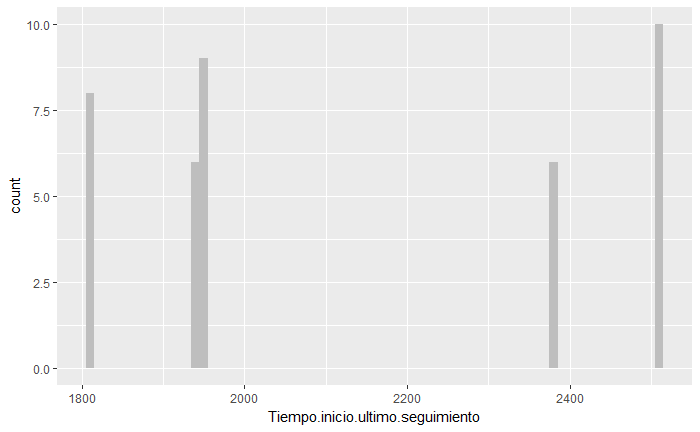

```r
library(ggplot2)
ggplot(chuvi) +
geom_histogram(aes(x=Tiempo.inicio.ultimo.seguimiento),
binwidth=10, fill="gray")
```

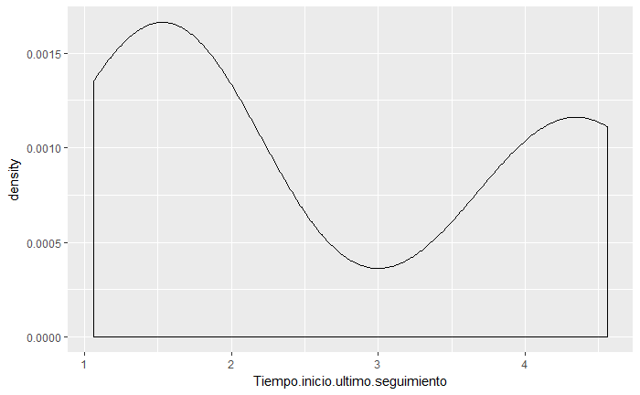

```r
library(ggplot2)
library(scales)
ggplot(chuvi) + geom_density(aes(x=Tiempo.inicio.ultimo.seguimiento)) +
scale_x_continuous(labels=time)
```

Es curioso observar cómo se distribuye la población para esta variable. A pesar de todos los datos que nos faltan, parece indicar que vienen de dos poblaciones completamente distintas.

## Tiempo desde implante

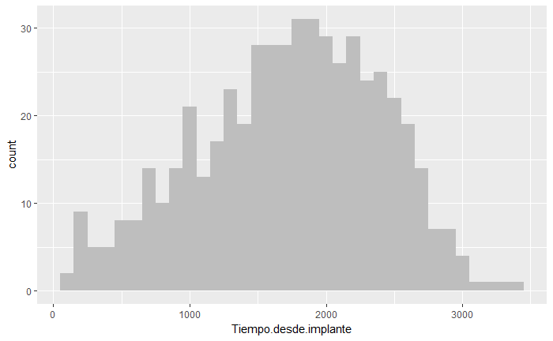

```r
library(ggplot2)
ggplot(chuvi) +
geom_histogram(aes(x=Tiempo.desde.implante),
binwidth=100, fill="gray")
```

Aquí ya vemos una distribución un poco más normal, si bien es posible que se vea mejor con el otro tipo de gráfica.

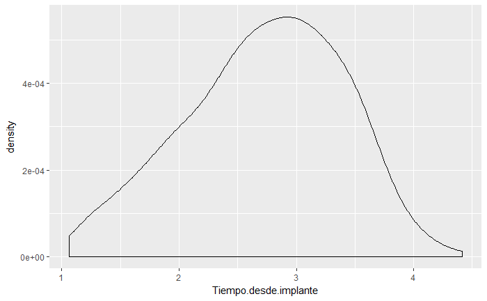

```r
library(ggplot2)
library(scales)
ggplot(chuvi) + geom_density(aes(x=Tiempo.desde.implante)) +
scale_x_continuous(labels=time)
```

## Tiempo hasta último seguimiento

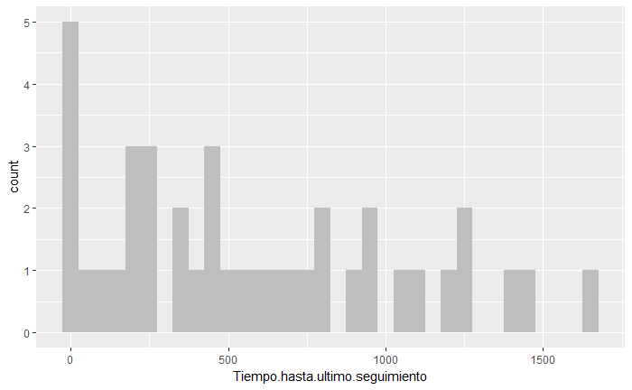

```r
library(ggplot2)
ggplot(chuvi) +
geom_histogram(aes(x=Tiempo.hasta.ultimo.seguimiento),
binwidth=50, fill="gray")
```

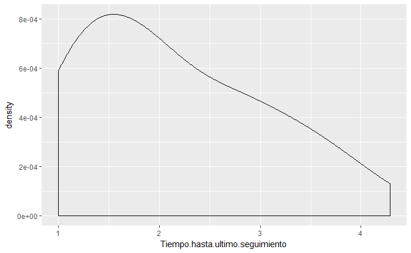

```r
library(ggplot2)
library(scales)
ggplot(chuvi) + geom_density(aes(x=Tiempo.hasta.ultimo.seguimiento)) +
scale_x_continuous(labels=time)
```

Aquí la distribución ya tiene una forma un poco más extraña. Para los valores que tenemos, se concenran más en los valores más pequeños: los que tienen menos tiempo hasta el último seguimiento. No es tan extraña si nos paramos a pensar que, en efecto, debe haber más citas cuanto más se acerca la cita en la que le retirarán el aparato, ya que esto es precisamente lo que nosotros queremos evitar.

Esta gráfica nos arroja mucha más luz que la anterior, a pesar de tener muchos menos datos, ya que los que teníamos para la anterior estaban condicionados de que no tenemos el seguimiento entero de los pacientes.

De nuevo, y por desgracia, nos vuelven a faltar muchísimos datos.

## Voltaje de la batería

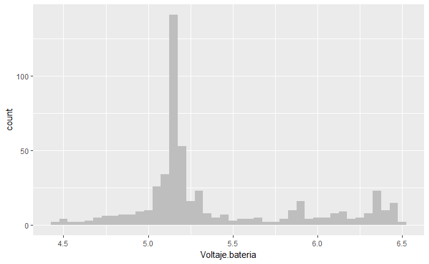

```r
library(ggplot2)
ggplot(chuvi) +
geom_histogram(aes(x=Voltaje.bateria),
binwidth=0.05, fill="gray")
```

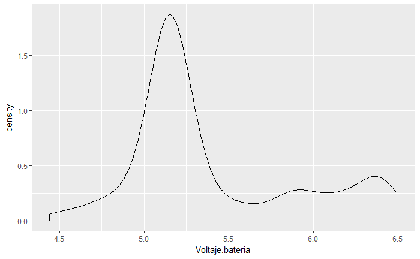

```r
library(ggplot2)
library(scales)
ggplot(chuvi) + geom_density(aes(x=Voltaje.bateria)) +
scale_x_continuous()
```

Los resultados de esta exploración son extremadamente extraños. Lo normal sería que, a lo largo del tiempo, la batería fuera bajando de forma normal y por lo tanto tuviéramos una distribución normal. Sin embargo, lo que observamos es un pico muy alto un poco por encima de los 5V, tras lo cual tenemos otros dos picos locales en casi 6V y casi 6.5V. De nuevo, puede deberse a que nuestra población está especialmente concentrada entre los periodos más tempranos del seguimiento, pero aún así no explica por qué el pico mayor está tan concentrado en el centro de la gráfica.

## Número de cámaras

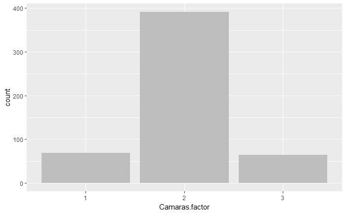

```r
ggplot(chuvi) + geom_bar(aes(x=Camaras.factor), fill="gray")
```

Ya lo habíamos adivinado al ver los números, pero tenemos muchos datos de 2 cámaras comparados con el resto. Es posible que pudiéramos centrarnos en el análisis de solo los de 2 cámaras para facilitar los resultados, o que pudiéramos realizar un clustering previo.

## Supervivencia

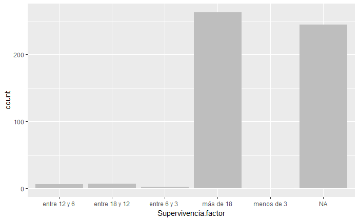

```r
ggplot(chuvi) + geom_bar(aes(x=Supervivencia.factor), fill="gray")
```

Otro resultado que se puede atribuir a la falta de datos. No sabemos cómo se distribuyen todos esos datos que faltan, pero son demasiados como para ignorarlos y fingir que el resto de los datos se comportan así. Idealmente, tendríamos que inferir los valores de alguna forma. ¿Pero cómo? ¿Encontrando alguna variable de la que dependan?

## Eri

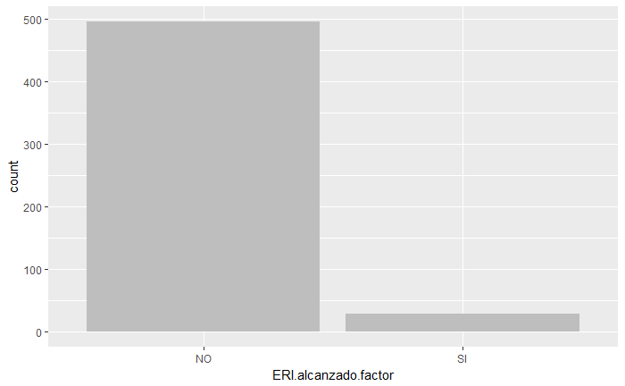

```r
ggplot(chuvi) + geom_bar(aes(x=ERI.alcanzado.factor), fill="gray")
```

## Variables de supervivencia

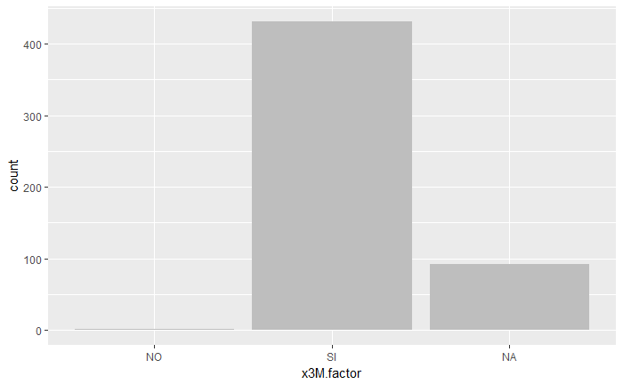

```r
ggplot(chuvi) + geom_bar(aes(x=x3M.factor), fill="gray")
```

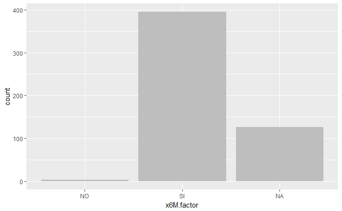

```r
ggplot(chuvi) + geom_bar(aes(x=x6M.factor), fill="gray")
```

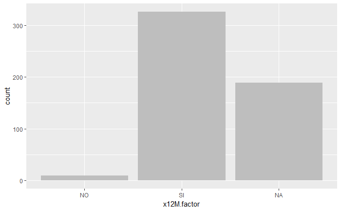

```r
ggplot(chuvi) + geom_bar(aes(x=x12M.factor), fill="gray")
```

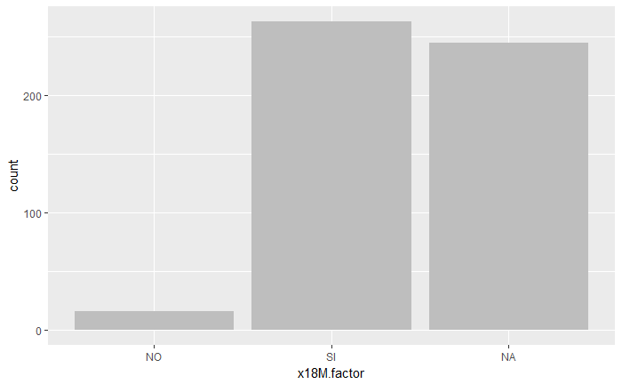

```r
ggplot(chuvi) + geom_bar(aes(x=x18M.factor), fill="gray")
```

De nuevo, nos faltan /demasiados/ datos. De nuevo, tenemos que plantearnos qué hacer con los datos que faltan. ¿Inferirlos a partir de otros datos?

Y creo que con esto hemos terminado con la exploración de variables solas. A partir de aquí, solo tiene sentido explorarlas si lo hacemos en función de alguna otra.

## Análisis de más de una variable

En primer lugar, me parece relevante estudiar cómo están distribuidas algunas variables en función del número de cámaras, ya que parece una variable un poco importante.

## Supervivencia vs. número de cámaras

Me parece interesante estudiar esta variable.

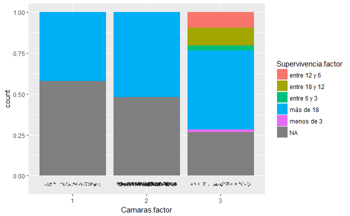

```r
ggplot(chuvi, aes(x=Camaras.factor)) +
geom_bar(aes(fill=Supervivencia.factor), position="fill") +
geom_point(aes(y=-0.05), size=0.75, alpha=0.3,
position=position_jitter(h=0.01))
```

Como podemos ver en los resultados, tanto para las cámaras de 1 como para las de 2, es categórico: o sobrevive más de 18 meses, o no sabemos cuánto sobrevive. Por otro lado, para el caso de la cámara de 3, tenemos un poco más de variedad. Esto nos puede presentar problemas a la hora de estudiar los datos: nos planteamos estudiar solo las cámaras de 3? Pero tenemos mucha más densidad de datos en el caso de la cámara de 2.

## Las otras variables de supervivencia en función del número de cámaras

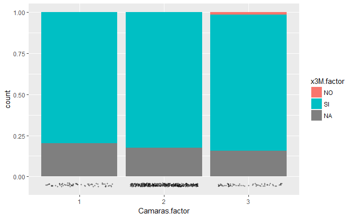

```r
ggplot(chuvi, aes(x=Camaras.factor)) +
geom_bar(aes(fill=x3M.factor), position="fill") +
geom_point(aes(y=-0.05), size=0.75, alpha=0.3,
position=position_jitter(h=0.01))
```

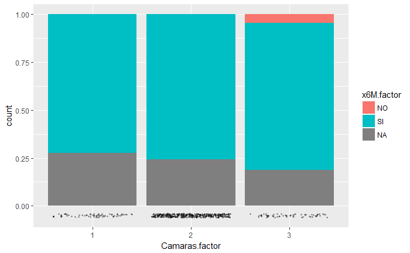

```r
ggplot(chuvi, aes(x=Camaras.factor)) +
geom_bar(aes(fill=x6M.factor), position="fill") +
geom_point(aes(y=-0.05), size=0.75, alpha=0.3,
position=position_jitter(h=0.01))
```

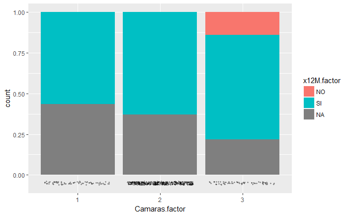

```r
ggplot(chuvi, aes(x=Camaras.factor)) +
geom_bar(aes(fill=x12M.factor), position="fill") +
geom_point(aes(y=-0.05), size=0.75, alpha=0.3,
position=position_jitter(h=0.01))
```

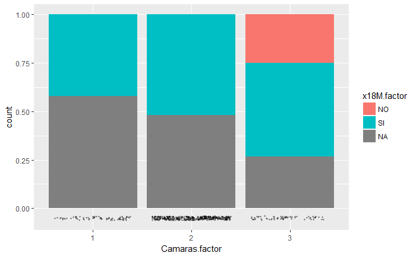

```r
ggplot(chuvi, aes(x=Camaras.factor)) +
geom_bar(aes(fill=x18M.factor), position="fill") +
geom_point(aes(y=-0.05), size=0.75, alpha=0.3,
position=position_jitter(h=0.01))
```

Nos encontramos de nuevo con que tenemos los “mejores” datos para el caso de las 3 cámaras, a pesar de que es el caso en el que menos datos tenemos. O los inferimos o nos sé qué hacer, sinceramente.

## Cámaras vs. ERI alcanzado

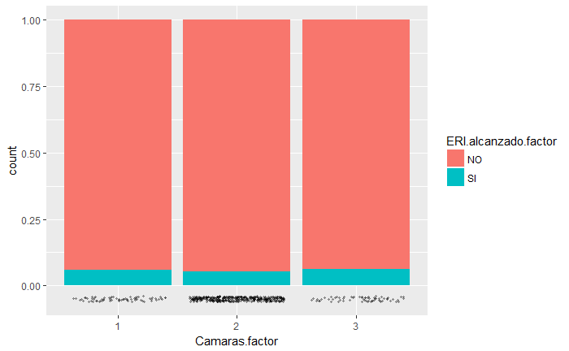

```r
ggplot(chuvi, aes(x=Camaras.factor)) +
geom_bar(aes(fill=ERI.alcanzado.factor), position="fill") +
geom_point(aes(y=-0.05), size=0.75, alpha=0.3,
position=position_jitter(h=0.01))
```

Por suerte, al menos en este caso parece que se distribuyen de una forma un poco más normal. Dentro de lo que cabe, para las tres cámaras tenemos casos en los que se ha alcanzado el ERI.

## Relación entre el tiempo desde el implante y el voltaje de la batería

```r
cor(chuvi$Tiempo.desde.implante, chuvi$Voltaje.bateria)
```

```
[1] -0.8610078
```

Hay correlación negativa, y además es bastante alta: estas dos variables están altamente correlacionadas.

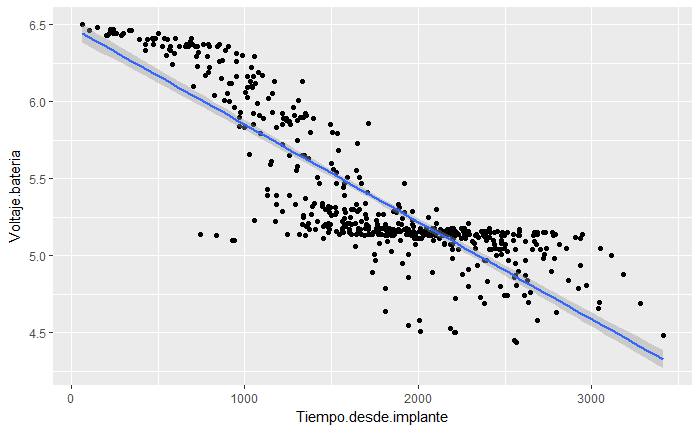

```r
ggplot(chuvi, aes(x=Tiempo.desde.implante, y=Voltaje.bateria)) +
geom_point() + stat_smooth(method="lm")
```

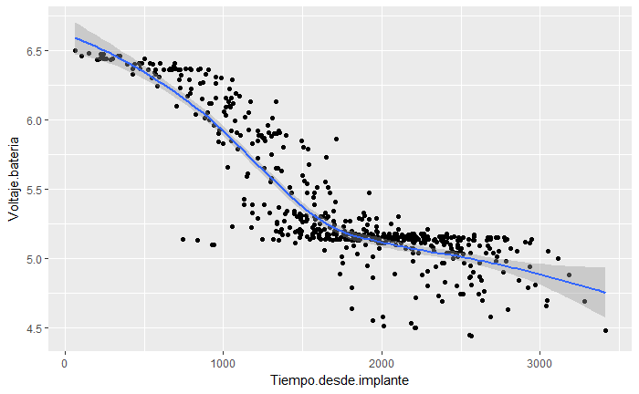

```r
ggplot(chuvi, aes(x=Tiempo.desde.implante, y=Voltaje.bateria)) +
geom_point() + geom_smooth()
```

aquí vemos sin duda unos resultados muy interesantes. Es bastante curioso cómo se distribuyen los niveles de la batería en función del tiempo.

## Voltaje de la batería frente al tiempo hasta el último seguimiento

Siguiendo la temática de tiempo vs. batería:

```r
cor(chuvi$Tiempo.hasta.ultimo.seguimiento, chuvi$Voltaje.bateria, use="complete.obs")
```

```
[1] 0.8650983
```

Vemos que la correlación da un valor bastante alto, y directo, cosa que tiene sentido.

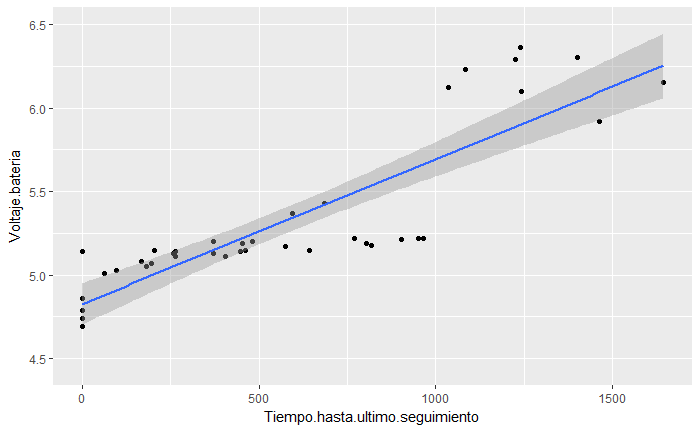

```r
ggplot(chuvi, aes(x=Tiempo.hasta.ultimo.seguimiento, y=Voltaje.bateria)) +
geom_point() + stat_smooth(method="lm")
```

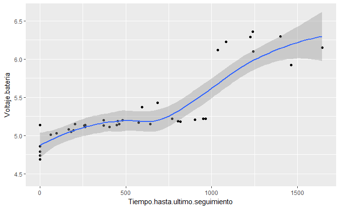

```r
ggplot(chuvi, aes(x=Tiempo.hasta.ultimo.seguimiento, y=Voltaje.bateria)) +
geom_point() + geom_smooth()
```

Bueno, de alguna forma vemos que se adecúa con los resultados anteriores. En vez de seguir una línea recta exacta, tiene como un punto en el que se estanca. Me pregunto a qué se debe.

## Relación entre tiempo desde el implante y tiempo hasta el último seguimiento

Solo por curiosidad, vamos a ver cuál es la relación entre el tiempo desde el implante y el tiempo hasta el último seguimiento.

Los resultados, por supuesto, tienen todo el sentido del mundo.

```r
cor(chuvi$Tiempo.hasta.ultimo.seguimiento, chuvi$Tiempo.desde.implante, use="complete.obs")
```

```
[1] -0.8346371
```

Vemos que también hay una correlación negativa entre el tiempo que lleva la batería implantada y el tiempo que queda para que le quiten el aparato. Obviamente, esto tiene sentido ya que también hay correlación con el voltaje de la batería, que ya solo de existir gasta batería.

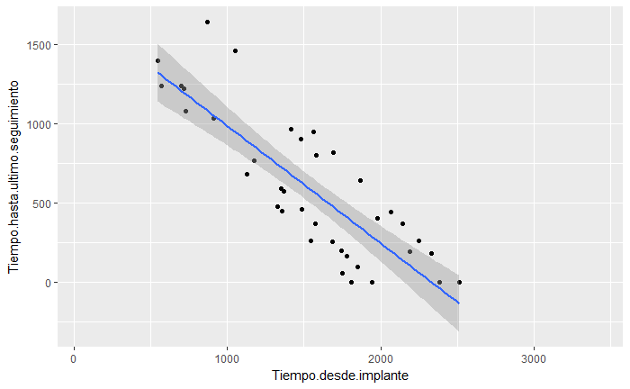

```r
ggplot(chuvi, aes(x=Tiempo.desde.implante, y=Tiempo.hasta.ultimo.seguimiento)) +
geom_point() + stat_smooth(method="lm")
```

Estoy un poco atascada así que igual es mejor dejarlo estar durante una temporadita.

## Tiempo entre inicio y último seguimiento VS. número de cámaras?

```r
cor(chuvi$Tiempo.inicio.ultimo.seguimiento, chuvi$Camaras, use="complete.obs")
```

```
the standard deviation is zero
```

```
[1] NA
```

Eeeeeeeen fin.

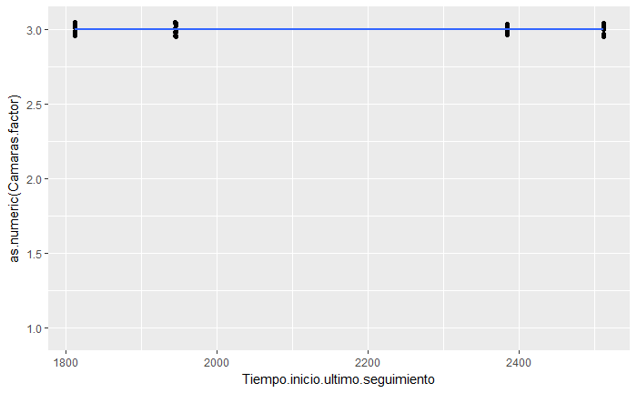

```r
ggplot(chuvi, aes(x=Tiempo.inicio.ultimo.seguimiento, y=as.numeric(Camaras.factor))) +
geom_point(position=position_jitter(w=0.05, h=0.05)) +
geom_smooth()
```

HM. INTERESANTE. Esto no nos sirve para nada lol. Quería ver si la distribución extraña de poblaciones se debía al distinto número de cámaras (y consiguientes distintas cantidades de trabajo para el dispositivo) pero ya veo que no puede ser.

## Supervivencia VS. Episodios

```r
cor(chuvi$Tiempo.inicio.ultimo.seguimiento, chuvi$Episodios, use="complete.obs")
```

```
the standard deviation is zero
```

```
[1] NA
```

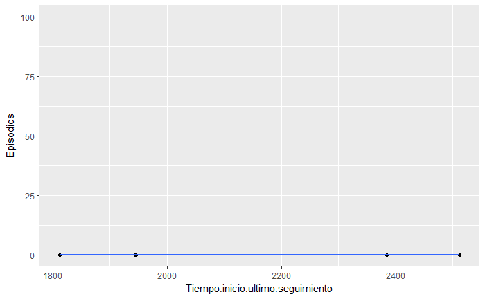

```r
ggplot(chuvi, aes(x=Tiempo.inicio.ultimo.seguimiento, y=Episodios)) +
geom_point(position=position_jitter(w=0.05, h=0.05)) +
geom_smooth() + ylim(0, 100)
```

Pueh nada. Como podemos ver, tampoco se puede deber a si hay o no episodios, ya que faltan datos para el caso de sí haber episodios.

## Todas las variables de programación VS. las variables de supervivencia, por partes

Vamos primero a organizarnos un poco: quiero ver todas las relaciones, y la mejor forma de hacerlo es organizarme. Tenemos las siguientes variables de supervivencia:

- Tiempo entre inicio y fin
- Tiempo hasta el fin de vida
- Supervivencia
- Voltaje batería
- Supervivencia 3, 6, 12, 18 meses

Prioridad de estas variables:

- Tiempo hasta el fin de vida
- Tiempo entre inicio fin
- Supervivencia
- Supervivencia distintos meses
- Voltaje batería

Y tenemos las siguientes variables de programación:

- Número de cámaras
- Estimulaciones: A, VI, VD
- Voltaje y MS de las estimulaciones: A, VI, VD
- Choque
- ATP
- Frecuencia mínima
- R

Prioridad de estas variables:

- número de cámaras
- Estimulaciones + voltaje
- Frecuencia mínima
- El resto

Empezamos pues

## Tiempo entre inicio y fin de vida VS. Estimulaciones + voltaje

```r
cor(chuvi$Tiempo.inicio.ultimo.seguimiento, chuvi$STIMA, use="complete.obs")
```

```
[1] 0.08218772
```

Como podemos ver, el valor de la correlación no es lo suficientemente alto para ser significativo.

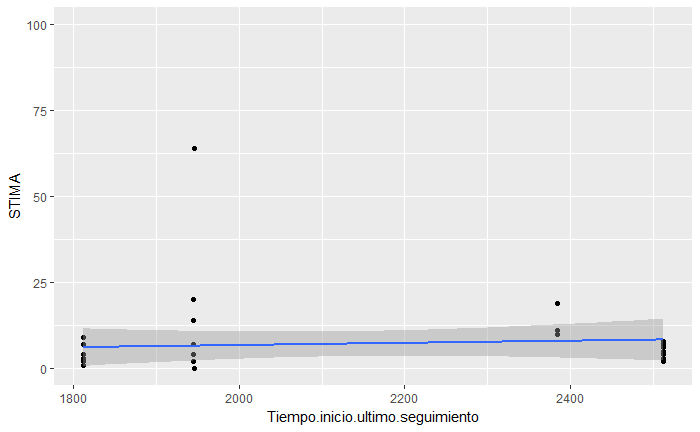

```r
library(ggplot2)
ggplot(chuvi, aes(x=Tiempo.inicio.ultimo.seguimiento, y=STIMA)) + geom_point() + stat_smooth(method="lm")
```

```r
cor(chuvi$Tiempo.inicio.ultimo.seguimiento, chuvi$STIMVD, use="complete.obs")
```

```
[1] 0.2327248
```

La correlación es un poco más alta esta vez, pero tampoco es lo suficientemente alta para ser algo significativo.

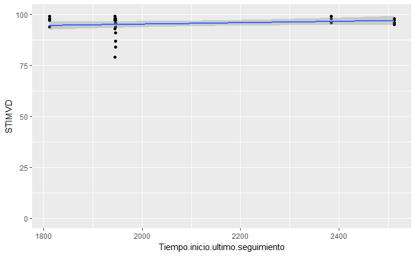

```r
library(ggplot2)
ggplot(chuvi, aes(x=Tiempo.inicio.ultimo.seguimiento, y=STIMVD)) + geom_point() + stat_smooth(method="lm")
```

```r
cor(chuvi$Tiempo.inicio.ultimo.seguimiento, chuvi$STIMVI, use="complete.obs")
```

```
[1] 0.2327248
```

Otro valor que no significa nada significativo.

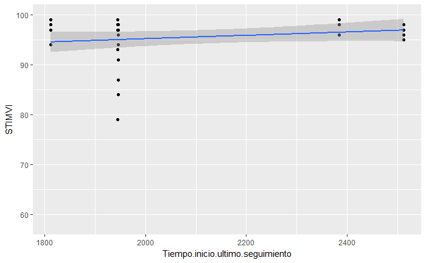

```r
library(ggplot2)
ggplot(chuvi, aes(x=Tiempo.inicio.ultimo.seguimiento, y=STIMVI)) + geom_point() + stat_smooth(method="lm")
```